# InClass 03/27/2018

```r
require("tree")
require("gbm")
require("randomForest")
require("ISLR")
```

# Decision Trees

## Exercise

We’re going to implement our own decision tree.

1. *Warm up*. Write a function called rss() that takes in a vector and returns the residual sum of squares (relative to the mean of the vector).
2. *Best Split*. We’re next going to write a function best_split() that will form the basis of a decision tree. This function will take in two arguments corresponding to a single predictor variable (ie, x) and a single target variable (ie, y). This function will identify the single location in the x domain that would yield the best split of the data, such that the two halves now each have least total RSS.

Some things to think about: (i) If your input x vector has *n* data points, how many possible split locations are there? (ii) You can accomplish this task by brute force. For every possible split location, split the data into two parts and compute the new total RSS. Then just return whichever split location was the optimal one.

Make sure your function returns a few things (perhaps in a list): the location of the x split, the mean of y for each of the split parts, the improvement in RSS that was acheived by the split.

3. *One Dimensional Data* Here is a synthetic data set with one predictor and one response. Use your function to find out where the first split would be if $y$ is predicted from $x$ with a regression tree.

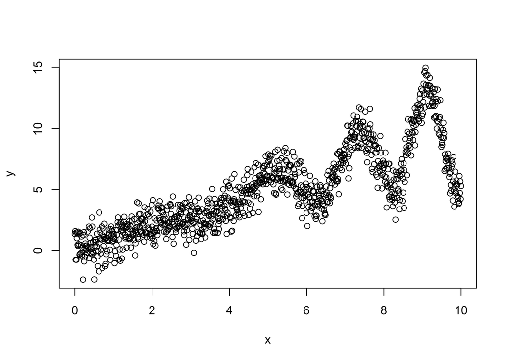

```r
x = seq(0,10,by = .01)
y0 = cos(x/4 + x^2/5)*x^2/20 + x
y = y0 + rnorm(length(x))
mydf = data.frame(x=x,y=y)
rss0 = 1000*var(y)
plot(x,y)
```

```r
#split0 <- bestsplit(x,y)
#split0
```

What is the total RSS of y? What this RSS reduced to when you split the data?

4. *Growing the Tree*

Split the lower half again. Split the upper half again. What is the total RSS now?

*Now With R* Now let’s make a tree using the R function.

```r
mytree = tree(y ~x, data = mydf)
names(mytree)
```

```
## [1] "frame"   "where"   "terms"   "call"    "y"       "weights"
```

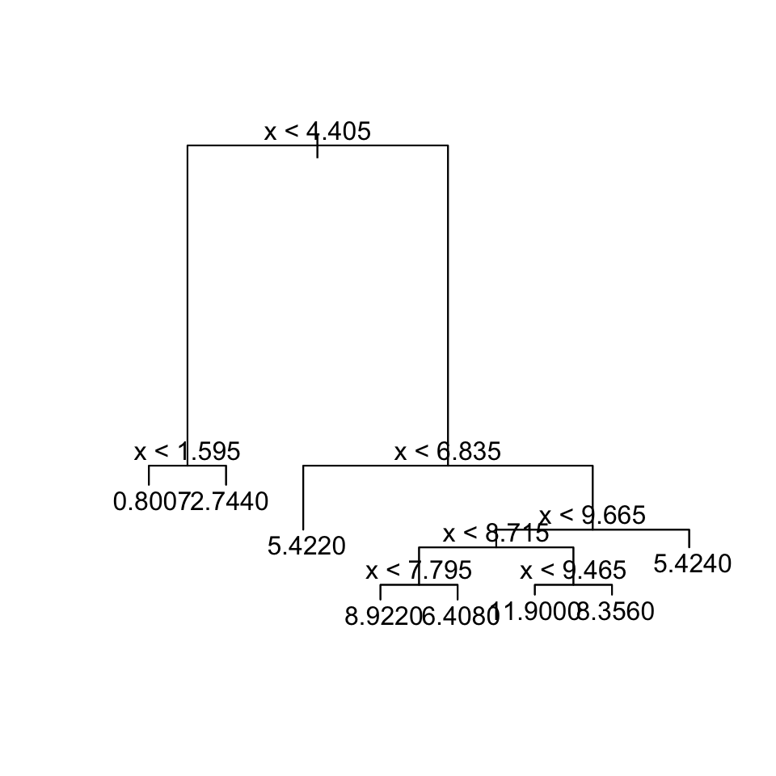

```r
plot(mytree)
text(mytree,pretty = 2)
```

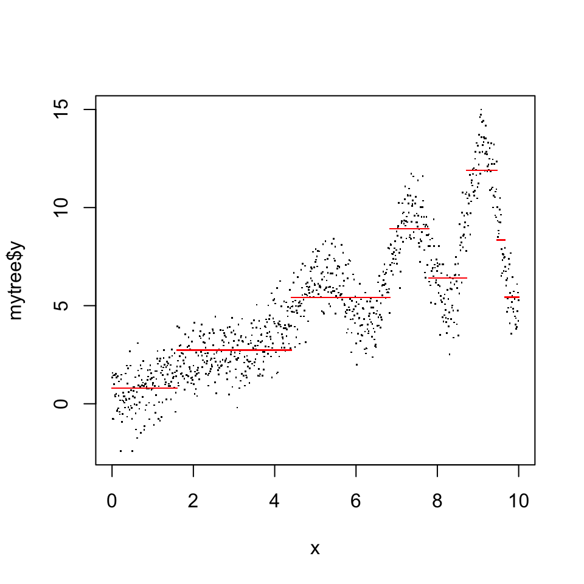

```r
plot(x,mytree$y, type= 'p', lwd = 2,pch = 46)
y.pred=predict(mytree,mydf,type= "vector")
points(x,y.pred, col = "red",pch = 46)
```

### Question

Now that we have a good understanding of how to do rescursive binary splitting of a single variable, how do we handle multiple predictors?

## Exercise

*Work with Abalone Data*. These data may be found on the [UC Irvine website](http://archive.ics.uci.edu/ml/). They give various physical characteristics of about 4000 abalone shellfish. The data were collected in Tasmania in 1995. Make sure that the data are in your source directory.

```r
load("abalone.RData")
head(abalone)
```

```
##   Sex Length Diameter Height WholeWeight ShuckedWeight VisceraWeight
## 1   M  0.455    0.365  0.095      0.5140        0.2245        0.1010
## 2   M  0.350    0.265  0.090      0.2255        0.0995        0.0485
## 3   F  0.530    0.420  0.135      0.6770        0.2565        0.1415
## 4   M  0.440    0.365  0.125      0.5160        0.2155        0.1140
## 5   I  0.330    0.255  0.080      0.2050        0.0895        0.0395
## 6   I  0.425    0.300  0.095      0.3515        0.1410        0.0775
##   ShellWeight Rings
## 1       0.150    15
## 2       0.070     7
## 3       0.210     9
## 4       0.155    10
## 5       0.055     7
## 6       0.120     8
```

1. We’ll try to predict the number of Rings, using the other features. Train a linear model as a baseline case.
2. Now build a tree and plot it. We can make the annotation of the tree look better by reducing the font size with the parameter. What is the depth of the tree? How many leaves does it have?
3. We can manually prune the tree to whatever depth we want. Use the function prune.tree() to simplify the tree so it only has 4 leaves. Visualize this tree.
4. Which two continuous predictors seem to be highly predictive according to the tree? Draw a sketch of the feature space and the splits in the space, as well as the predicted number of Rings for each region.
5. Decision trees have high variance. Split the Abalone data in half and train two trees (and don’t worry about any extra pruning). Observe the differences between them, visualize the two different trees.

# Ensemble Methods

### Question

What are the downsides of Decision Trees? There are three Ensembling techniques that we can use: Bagging, Random Forest, and Boosting. What are the conceptual differences between these?

## Exercise. Implement bagging.

1. Split the Abalone data into 80-20 Train/Test sets.
2. Using the Training data (the 80%) fit a regression tree. Evaluate Test error.
3. Using the Training data (the 80%), we’ll implement bagging. Use sample-with-replacement to create 500 boostrap replicates of the training data and fit a tree to each one.
4. Now make new predictions on the test data by averaging the predictions of the 500 boostrap trees. How does this Test Error compare with part (a)?

## Exercise

Let’s explore the airfoil data. We’re going to try to predict the “Pressure” feature from the other features.

1. Start with some exploratory visualizations to see how the other features are related to Pressure. Feel free to use pairs(), or scatterplots, or boxplots. Do any features seem to be strongly predictive of Pressure?
2. Fit a linear model, observe the $R^2$.
3. Fit using one of the Ensembling methods, observe the $R^2$. Feel free to use R libraries, you don’t need to implement these yourself.